# Homework1 (PP)

Pavlo Potseluiev

October 27, 2016

# Given Task

1. Load the `PogromcyDanych` package
2. Use the `setLang()` function to translate columns names into English.
3. For the dataset `skiJumps2013` present numerical and graphical summaries for following variables: jumpSpeed, jumpDistance, compCountry, jumperCountry, jumperDateOfBirth.
4. Create a report in `knitr` with these summaries. Use only competitions in 2014 year.

# Solution

## 1

First of all, we will install & load packages `PogromcyDanych` and `knitr` which are required for this task. Required `dplyr` package will be loaded automatically.

```
##
##  C:\Users\p_000\AppData\Local\Temp\RtmpWENJMr\downloaded_packages
```

```
##
##  C:\Users\p_000\AppData\Local\Temp\RtmpWENJMr\downloaded_packages
```

## 2

We need to translate columns names from Polish into English. We will use the setLang() function.

## 3

Third task is about presentation of summary: numerical and graphical types. We should use them for different variables.

Let’s check if the data was loaded correctly. We will cut an output for only 5 rows:

```
##   jumperSurname jumperName compName compCountry   compDate
## 1        AHONEN      JANNE  Kuusamo     Finland 2013-10-29
## 2        AMMANN      SIMON  Kuusamo     Finland 2013-10-29
## 3        AMMANN      SIMON  Kuusamo     Finland 2013-10-29
## 4     ASIKAINEN      LAURI  Kuusamo     Finland 2013-10-29
## 5        BIEGUN  KRZYSZTOF  Kuusamo     Finland 2013-10-29
```

Now we will assign different variables for different rows (jump_speed, jump_distance, comp_country, jumper_Country, jumper_DOB)

By the way, as it was told in the task 4, we will need only data from the 2014. So we have to different solutions: we can use subset(valuesNames, as.Date(compDate) > “2013-12-31”) each time we are using the data, Or we can cut off the 2013 data with the same subset function applied to the whole data set:

Again, let’s check if the data was filtered out correctly:

```
##     jumperSurname jumperName               compName compCountry   compDate
## 690        AHONEN      JANNE Garmisch-Partenkirchen     Germany 2014-01-01
## 691        AHONEN      JANNE Garmisch-Partenkirchen     Germany 2014-01-01
## 692        AMMANN      SIMON Garmisch-Partenkirchen     Germany 2014-01-01
## 693        AMMANN      SIMON Garmisch-Partenkirchen     Germany 2014-01-01
## 694        BARDAL     ANDERS Garmisch-Partenkirchen     Germany 2014-01-01
```

Now we will rewrite variables with the new data:

### Numerical summaries

Now let’s provide the numerical summeries for the given values. Note that we have to use different functions (table, summary) for different type of variables. We will cut only first 10 lines of each representation Jump Speed

```
##    Min. 1st Qu.  Median    Mean 3rd Qu.    Max.
##    0.00   89.80   90.70   91.98   93.60  101.50
```

Jump Dist.

```
##    Min. 1st Qu.  Median    Mean 3rd Qu.    Max.
##     0.0   119.5   126.0   127.5   132.5   199.0
```

Comp Country

```
## comp_country
##  Austria  Finland  Germany    Japan   Norway   Poland Slovenia   Sweden
##      268      239      241      163      160      130      159       81
```

Jumper Country

```
## jumper_country
## AUT BUL CAN CZE EST FIN FRA GER GRE ITA JPN KOR NOR POL ROU RUS SLO SUI
## 226   3  12 131  14  79  19 198   2  25 115   2 153 158   3  42 201  54
## USA
##   4
```

Date of birth

```
##         Min.      1st Qu.       Median         Mean      3rd Qu.
## "1970-10-26" "1985-02-17" "1989-05-28" "1988-01-20" "1991-06-24"
##         Max.
## "1997-07-09"
```

### Graphic summaries

We can also build some nice graphic representation of each row.

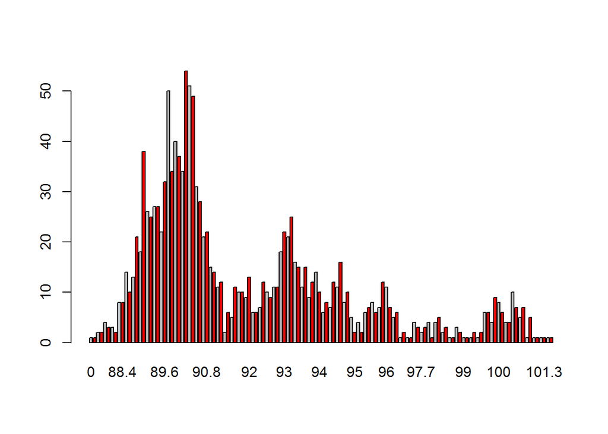

Jump Speed

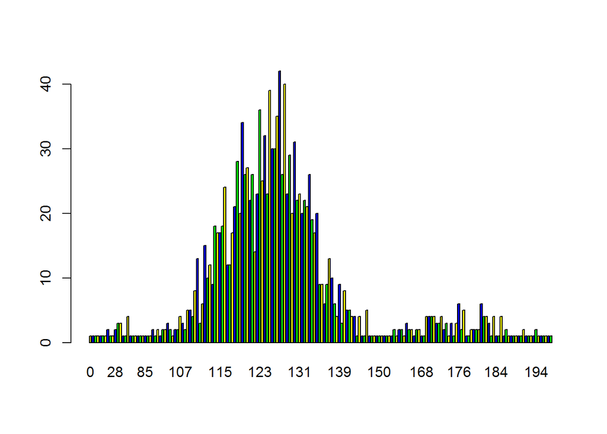

Jump Distance

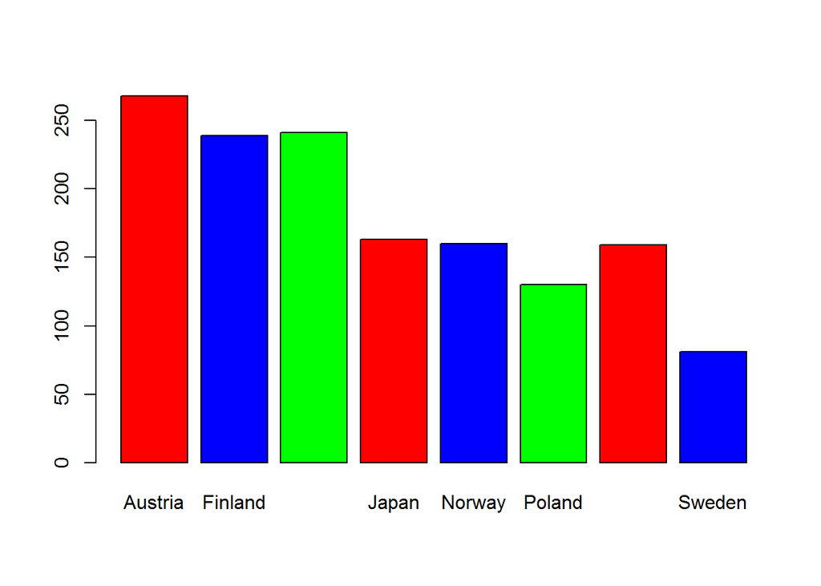

Comp. country

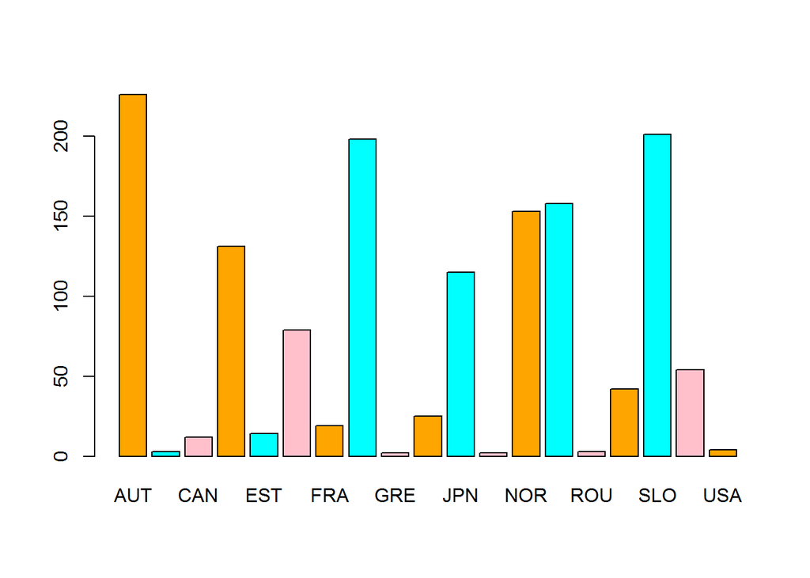

Jumper Country

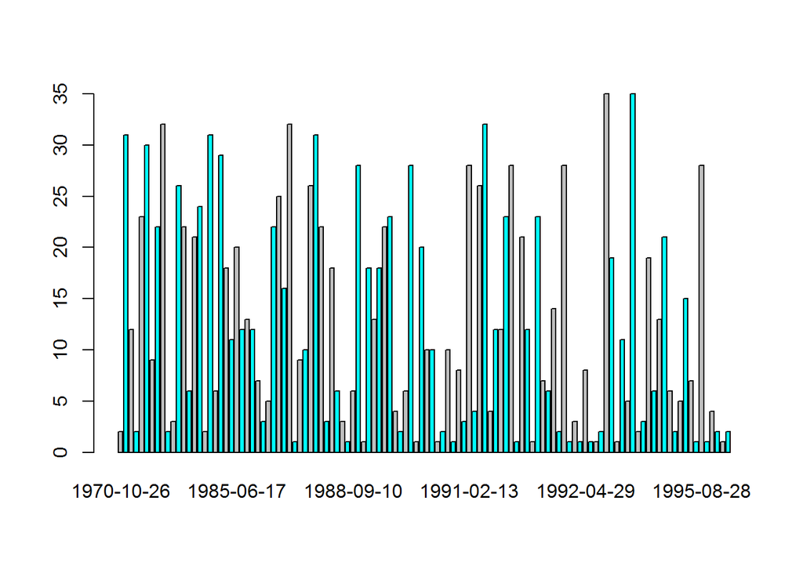

Jumper date of birth

# 4

This report was generated with the knitr.